# Introduction to Machine Learning in R

Konstantin Klemmer, Imperial College London and ICDSS

28 February 2017

This tutorial is the transcript of a Machine Learning workshop hosted as a part of the **[Imperial College Data Science Society (ICDSS)](https://union.ic.ac.uk/guilds/icdss/)** talent development programme. The event aimed at conveying a basic understanding of Machine Learning using comprehensive case studies. This document targets Machine Learning beginners and requires some elementary experience with R. We first introduce the fundamental concepts of Machine Learning and then work through three exercises using **K-means Clustering**, **Artificial Neural Networks** and **Support Vector Machines**.

# What is Machine Learning?

Machine Learning describes the ‘*principles*, *methods* and *algorithms* for **learning and prediction** on the basis of **past evidence**’. Some examples of Machine Learning applications in our daily lives are Apples’ Siri (speech recognition), email spam filters (text filtering) or autonomous vehicles.

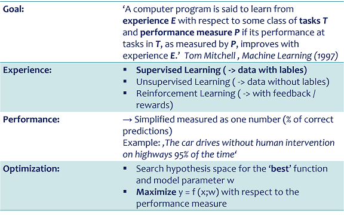

(A basic Machine Learning framework)

## Machine Learning Methodologies

**Supervised Learning** is concerned with the task of inferring a function from a set of labled training data. These datasets include both the input as well as the desired output. Thus, the algorithm learns how input affects output and enables prediction.

**Unsupervised Learning** describes methods that aim at finding hidden structure in unlabled datasets. Since the model is not provided with the correct results during training, there is no error or reward process to evaluate the potential solution.

Machine Learning models estimate a function $f:X \rightarrow Y$ for output $Y$ using input $X$. The concrete method depends on the nature of what is to be predicted and includes approaches such as:

- Regression (Prediction of real, continuous numbers)
- Classification (Prediction of discrete clas lables)
- Clustering (Finding structure in data by clustering points according to their proximities)

We now work through some of those techniques, to get some basic insights on how Machine Learning is applied in R. The examples will demonstrate how powerful the algorithms are, and how different modelling approaches may be compared.

# K-means clustering

Our goal is to assign our data points to a predefined number of clusters, where each point belongs to the cluster with the closest mean. Initially, we generate random points to serve as cluster means, assign our observations, compute new cluster means and repeat the assignment until convergance. This process is known as **LLoyd’s algorithm**.

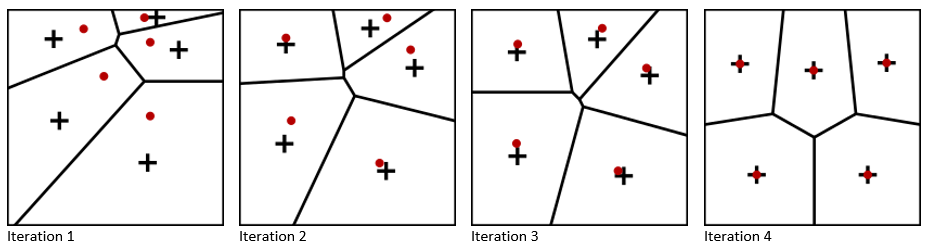

(Source: https://en.wikipedia.org/wiki/Lloyd%27s_algorithm)

K-means clustering can be applied in R with only a few commands:

We load the required packages and prepare our dataset. Note that we already load the packages for this whole tutorial. The dataset called `countries` can be found on my website.

```r
#Check whether required packages are installed and install missing packages
pkgs <- c("ggplot2","nnet","caret","e1071","pROC")
for (pkg in pkgs) {
  if(pkg %in% rownames(installed.packages()) == FALSE) {install.packages(pkg)}}
#Loading data
countries <- read.csv("http://konstantinklemmer.github.io/data/countries.csv",header=TRUE,row.names=1)
```

Before we start, let’s explore the data: Our sample represents various countries, characterised by respective numbers for income per capita, literacy rate, infant mortality and life expectancy. Based on these attributes, we seek to cluster those countries into groups.

```r
head(countries)
```

```
##            Per.capita.income Literacy Infant.mortality Life.expectancy
## Brazil                 10326     90.0            23.60            75.4
## Germany                39650     99.0             4.08            79.4
## Mozambique               830     38.7            95.90            42.1
## Australia              43163     99.0             4.57            81.2
## China                   5300     90.9            23.00            73.0
## Argentina              13308     97.2            13.40            75.3
```

To start off, we apply the clustering algorithm using the `kmeans` command. We choose a initial number of $k=3$ cluster means - this choice seems somewhat arbitrary, however we will expand the model later.

```r
#Running k-means clustering for 3 clusters and nstart=10 random sets
km <- kmeans(countries, 3, nstart = 10)
km
```

```
## K-means clustering with 3 clusters of sizes 5, 7, 7
##
## Cluster means:
##   Per.capita.income Literacy Infant.mortality Life.expectancy
## 1         13370.400    91.58        23.560000        68.96000
## 2         35642.143    98.50         4.477143        80.42857
## 3          3267.286    70.50        56.251429        58.80000
##
## Clustering vector:
##         Brazil        Germany     Mozambique      Australia          China
##              1              2              3              2              3
##      Argentina United Kingdom   South Africa         Zambia        Namibia
##              1              2              1              3              3
##        Georgia       Pakistan          India         Turkey         Sweden
##              3              3              3              1              2
##      Lithuania         Greece          Italy          Japan
##              1              2              2              2
##
## Within cluster sum of squares by cluster:
## [1]  57626083 158883600  20109876
##  (between_SS / total_SS =  94.1 %)
##
## Available components:
##
## [1] "cluster"      "centers"      "totss"        "withinss"
## [5] "tot.withinss" "betweenss"    "size"         "iter"
## [9] "ifault"
```

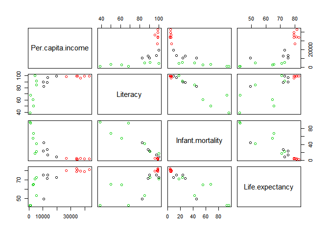

```r
plot(countries, col = km$cluster)
```

The plot shows cluster assignment by attributes and gives more detailed insight into the different characteristics. We can display these relations a little bit more applealing by using `ggplot2`, a great plotting package in R. Here’s the examplary cluster assignment comparing infant mortality and per capita income:

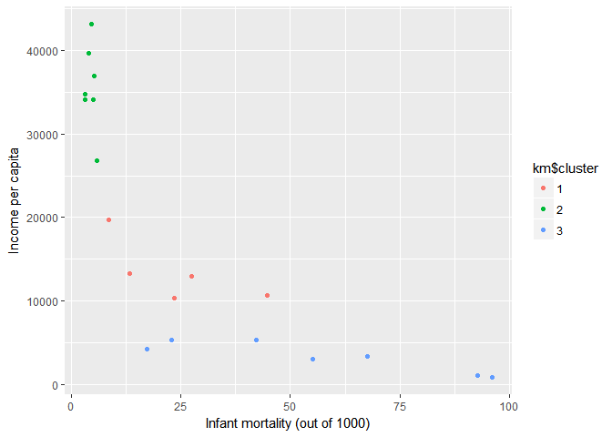

```r
library(ggplot2)
km$cluster <- as.factor(km$cluster)
ggplot(countries, aes(Infant.mortality, Per.capita.income, color = km$cluster)) +
      geom_point() +
      xlab("Infant mortality (out of 1000)") +
      ylab("Income per capita")
```

Depending on the number of clusters, the k-means algorithm can be rather computationally expensive. We must cope with a trade-off between explanatory power and computational efficiency. A good tool to investigate this relation and help with decision making is the **elbow plot**, plotting the number of clusters against the explained variance in our model.

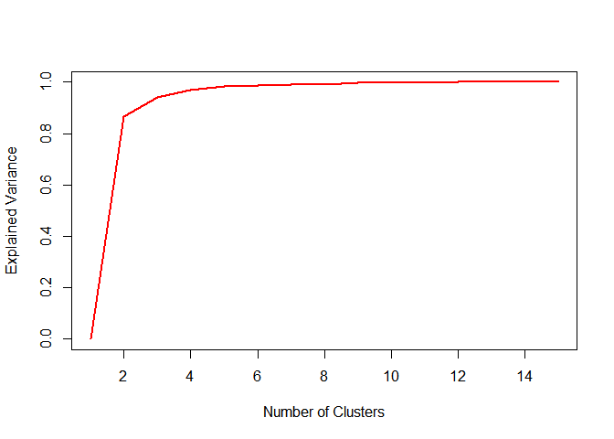

```r
ev <- c()
for (i in 1:15) {
km <- kmeans(countries, i, nstart = 10)
ev[i] <- sum(km$betweenss)/km$totss
}
plot(1:15, ev, col="red", lwd=2, type = "l", xlab = "Number of Clusters", ylab = "Explained Variance")
```

We usually select a number of clusters $k$, so that adding another cluster does not result in explicitly better modelling of our data. For more information on k-means in R, check this [tutorial](https://www.r-bloggers.com/k-means-clustering-in-r/).

# Artificial Neural Networks

*Artificial Neural Networks (ANN)* are computational models inspired by the central nervous system. It computes a function by feeding information through a **network of neurons**. Neurons are arranged in a set of layers, reaching from the input layer (recipient of the input data) over varied numbers of hidden layers (connecting input and output) to an output layer (obtaining the response values).

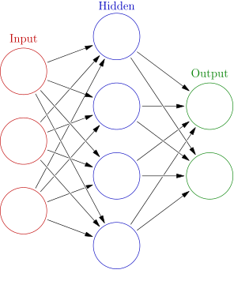

(Source: https://en.wikipedia.org/wiki/Artificial_neural_network)

The input of each neuron in the network is the weighted sum of all previous neurons.

```r
#Loading required libraries nnet and ggplot2 (for dataviz)
library(ggplot2)
library(nnet)
#Accessing credit scores
library(caret)
data(GermanCredit)
#Split data into index subset for training (80%) and testing (20%) instances
inTrain <- runif(nrow(GermanCredit)) < 0.2
```

The dataset `GermanCredit` includes credit approval data as well as attributes characterising credit applications, such as income, gender, housing situation or credit purpose. We seek to find patterns in the dataset that help with predicting credit application outcomes, as given by the column `Class`.

We train the ANN using the R command `nnet`, specifiying the number of hidden layer units, maximum iterations, initial random weights and weight decay.

```r
#Train neural network with n nodes in the hidden layer via nnet(formula, data=d, size=n ...)
#Output variable: Class (binary 'accept credit application y/n')
nn <- nnet(Class ~ ., data=GermanCredit[inTrain,],
size=15, maxit=100, rang=0.1, decay=5e-4)
```

We use the results obtained from the ANN to predict credit application outcomes and compare the prediction with the actual values. We extract the [confusion matrix](https://en.wikipedia.org/wiki/Confusion_matrix), providing us with true positive (correctly predicted good outcome), true negative (correctly predicted bad outcome), false positive (falsely predicted good outcome) and false negative (falsely predicted bad outcome) values of our prediction.

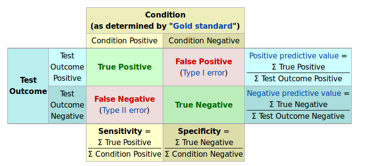

Source: https://en.wikipedia.org/wiki/Sensitivity_and_specificity

Using these numbers, we can compute model **accuracy** ($ACC=(TP+TN)/(TP+TN+FP+FN)$) and **precision** ($PRE=TP/(TP+FP)$). Both are major indicators of model quality.

```r
#Predict credit scores via
#predict(nn, test, type="class")
pred <- predict(nn, GermanCredit[-inTrain,],
type="class")
#Extract confusion matrix via
#table(pred=pred_classes, true=true_classes)
cm_nn <- table(pred=pred, true=GermanCredit$Class[-inTrain])
cm_nn
```

```
##       true
## pred   Bad Good
##   Bad   94   97
##   Good 206  602
```

The confusion matrix `cm_nn` shows that most of our predictions are accurate. Still, 206 application outcomes are wrongly predicted to be ‘Good’ and 97 are wrongly predicted ‘Bad’.

There are different ways to extract accuracy and precision values from the model. Below we compute those number and plot the confusion matrix using `ggplot2`.

```r
#Calculating accuracy
(cm_nn[1,1]+cm_nn[2,2])/(cm_nn[1,1]+cm_nn[1,2]+cm_nn[2,1]+cm_nn[2,2])
```

```
## [1] 0.6966967
```

```r
#Alternative that works also for multi-class data
sum(diag(cm_nn))/sum(sum(cm_nn))
```

```
## [1] 0.6966967
```

```r
#Calculating precision
cm_nn[1, 1]/(cm_nn[1, 1] + cm_nn[1, 2])
```

```
## [1] 0.4921466
```

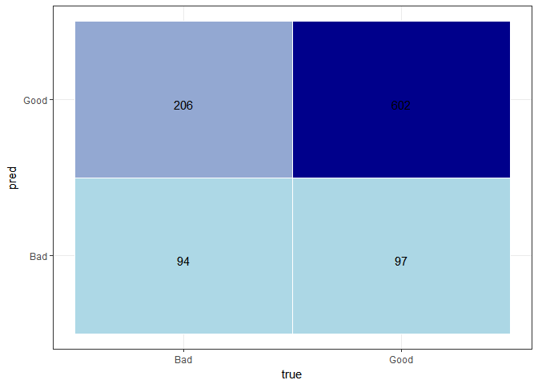

```r
#Plot confusion matrix using ggplot 2
cm_nn_plot <- as.data.frame(cm_nn)
ggplot(data =  cm_nn_plot, mapping = aes(x = true, y = pred)) +
  geom_tile(aes(fill = Freq), colour = "white") +
  geom_text(aes(label = sprintf("%1.0f", Freq)), vjust = 1) +
  scale_fill_gradient(low = "light blue", high = "dark blue") +
  theme_bw() + theme(legend.position = "none")
```

Our ANN shows an accuracy of around $0.7$, impyling that approximately 70% of the credit application outcome predictions are accurate. This is already a pretty good outcome, but can we find a technique that surpasses this performance?

# Support Vector Machines

A *Support Vector Machine (SVM)* is a linear seperator technique, that aims at maximizing the margins between the linear seperator and the closest respective data points, called **support vectors**.

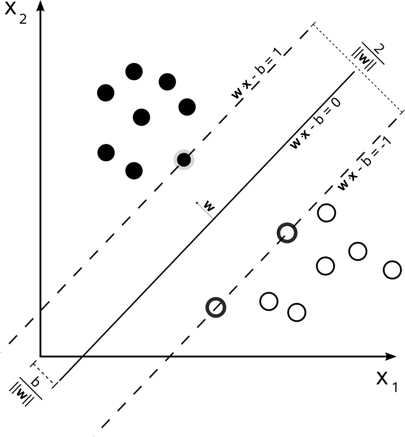

Source: https://en.wikipedia.org/wiki/Support_vector_machine

SVMs are extremely adaptable and can be used for supervised and unsupervised learning tasks. Some applications of SVM include Support Vector Regression or Support Vector Clustering.

```r
#Loading required library e1071
library(e1071)
#Split data into index subsets for training (80%) and testing (20%) instances
inTrain <- runif(nrow(GermanCredit)) < 0.2
```

We train a SVM in R, calling the `svm` command and specifiying machine type and variable scaling. We then extract the results for further assessment.

```r
#Train support vector machine for classification via svm(formula, data=d, type="C-classification")
#First row gives predicted outcomes, second are actual (true) values
model <- svm(Class ~ ., data=GermanCredit[inTrain,], type="C-classification", scale=FALSE)
#Predict credit scores for testing instances test via predict(svm, test)
pred <- predict(model, GermanCredit[-inTrain, ])
head(cbind(pred, GermanCredit$Class[-inTrain]))
```

```
##   pred
## 2    1 1
## 3    2 2
## 4    2 2
## 5    2 1
## 6    2 2
## 7    2 2
```

We again predict credit application outcomes and compare our results to the actual outcomes using a confusion matrix, accuracy and precision values.

```r
#Confusion matrix via table(pred=pred_classes, true=true_classes)
cm_svm <- table(pred=pred, true=GermanCredit$Class[-inTrain])
cm_svm
```

```
##       true
## pred   Bad Good
##   Bad   65    1
##   Good 235  698
```

Interestingly, the confusion matrix `cm_svm` shows that the model errors are distributed quite unregularly. While 235 predicted ‘Good’ outcomes are actually ‘Bad’, only 1 ‘Good’ outcome is wrongly predicted to be ‘Bad’. Now, we can again compute accuracy and precision values and extract plot the confusion matrix.

```r
#Calculate accuracy
sum(diag(cm_svm))/sum(sum(cm_svm))
```

```
## [1] 0.7637638
```

```r
#Calculating precision
cm_svm[1, 1]/(cm_svm[1, 1] + cm_svm[1, 2])
```

```
## [1] 0.9848485
```

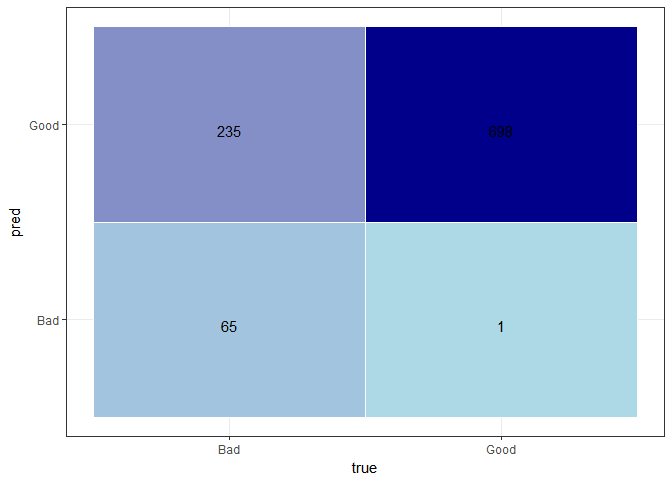

```r
#Plot confusion matrix using ggplot 2
cm_svm_plot <- as.data.frame(cm_svm)
ggplot(data =  cm_svm_plot, mapping = aes(x = true, y = pred)) +
  geom_tile(aes(fill = Freq), colour = "white") +
  geom_text(aes(label = sprintf("%1.0f", Freq)), vjust = 1) +
  scale_fill_gradient(low = "light blue", high = "dark blue") +
  theme_bw() + theme(legend.position = "none")
```

The accuracy for the SVM approach is approximately $0.76$, thus slightly improving on the model performance of the ANN.

## Receiver Operating Characteristic (ROC)

Lastly, I want to present a useful indicator of model quality. The ROC illustrates the performance of binary classifiers, as their discrimination threshold is varied. ROCs can be used to compare the quality of different models by comparing their respective areas under the curve (AUCs).

In R, we produce a ROC for our last model (SVM) by plotting the model **sensitivity** ($SEN=TP/(TP+FN)$) against **1 - specificity** ($SPC=TN/(FP+TN)$). We can extract those values from model confusion matrix.

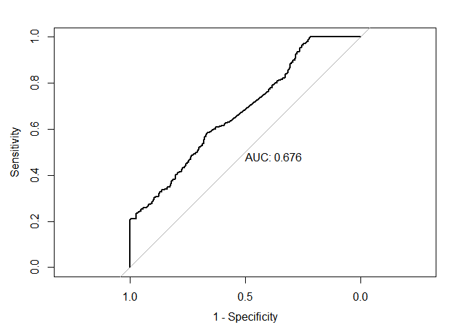

```r
#Load required library pROC
library(pROC)
#Perform prediction and retrieve decision values dv
pred <- predict(model, GermanCredit[-inTrain,], decision.values=TRUE)
dv <- attributes(pred)$decision.values
#Plot ROC curve
plot.roc(as.numeric(GermanCredit$Class[-inTrain]), dv, xlab = "1 - Specificity", print.auc=TRUE)
```

The grey diagonal line represents random guessing (50% accuracy) and every ROC curve above this line implies an model-induced improvement over a random guess. the ROC curve for our SVM approach is clearly above the diagonal line, which also shows in the AUC value.

This concludes my brief tutorial for **Machine Learning in R**. I hope you enjoyed the exercises and that I could convey some of my personal enthusiasm for Machine Learning. If you have and questions or feedback regarding this tutorial, feel free to drop me an (email) anytime.

# References

[Max Kuhn. Applied Predictive Modeling](https://static1.squarespace.com/static/51156277e4b0b8b2ffe11c00/t/56a1150d4bf11845241980ee/1453397275772/CIRUG.pdf)

[Gareth James, Daniela Witten, Trevor Hastie and Robert Tibshirani. An Introduction to Statistical Learning with Applications in R](http://www-bcf.usc.edu/~gareth/ISL/)

[Allison Chang. R for Machine Learning](https://ocw.mit.edu/courses/sloan-school-of-management/15-097-prediction-machine-learning-and-statistics-spring-2012/lecture-notes/MIT15_097S12_lec02.pdf)

This tutorial is vaguely based on the course *Business Intelligence (Summer term 2014)*, thaught by the *Chair of Information Systems Research, University of Freiburg*.